# Where are people moving in the UK

David Jones

03/05/2021

## UK Housing Trends During the Pandemic

This report details the variation in housing sales between January 2020 and March 2021. Analysis is performed on information on all residential sales available from the UK land registry price paid data set.

## Total Supply and Demand

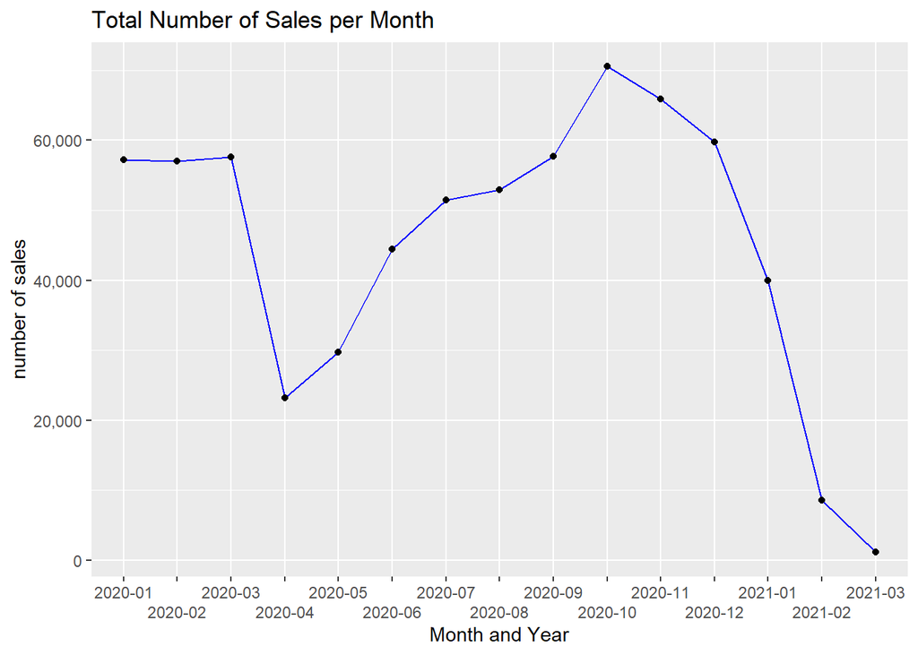

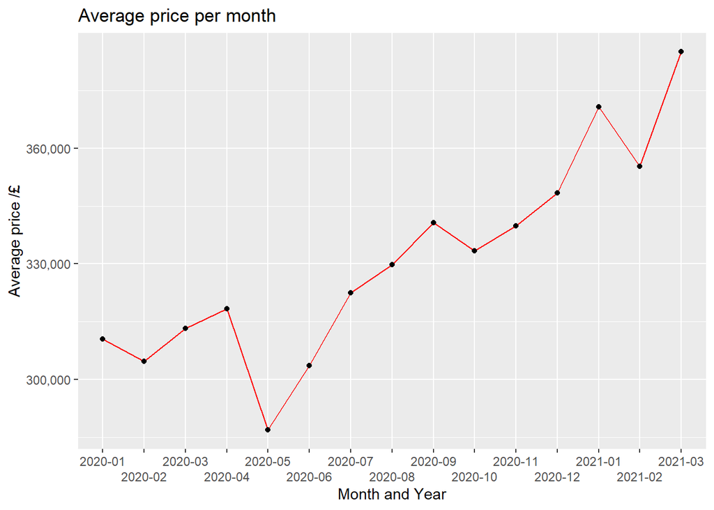

Within this overall picture of increasing demand and reducing supply, one category of housing bucks the trend. Flats - including housing options such as apartments, studios, etc. show a flat average price over the same period while all discrete housing types - detached, semi-detached and terraced have all been met with steady increases. Buyers then appear to be valuing the additional space available with these types over the usual value proposition of a flat. The prices of flats have actually converged to the price for semi-detached houses whereas previously they were generally more expensive.

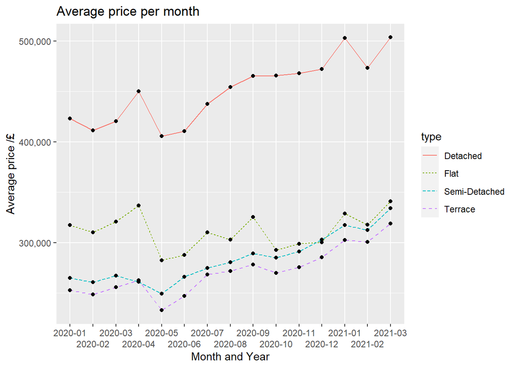